# Reporting survival analysis results with the {gtsummary} and {ggsurvfit} packages

NYR Conference 2024

Emily C. Zabor

## Time-to-event endpoints are common in biomedical research

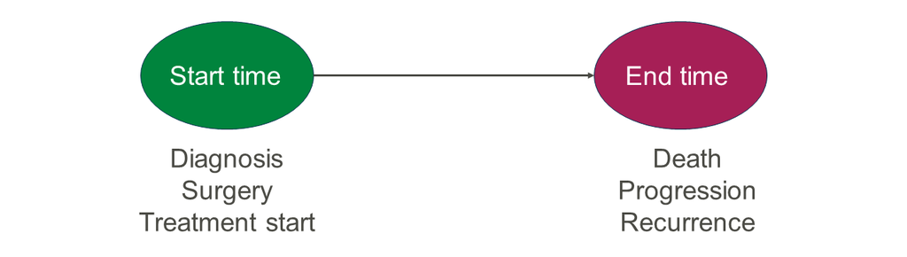

## Common research questions relate to times and probabilities

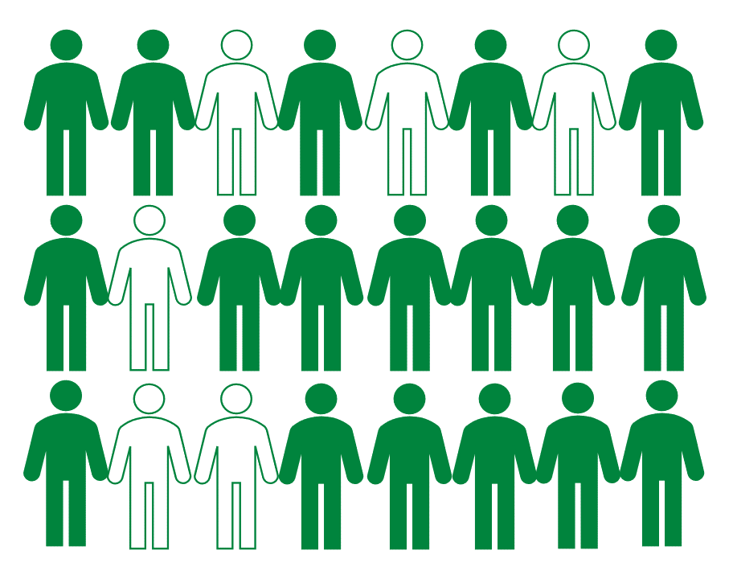

- What is the probability of remaining event-free for a certain number of years?
- What is the average amount of event-free time?

## Survival analysis methods needed when follow-up time varies

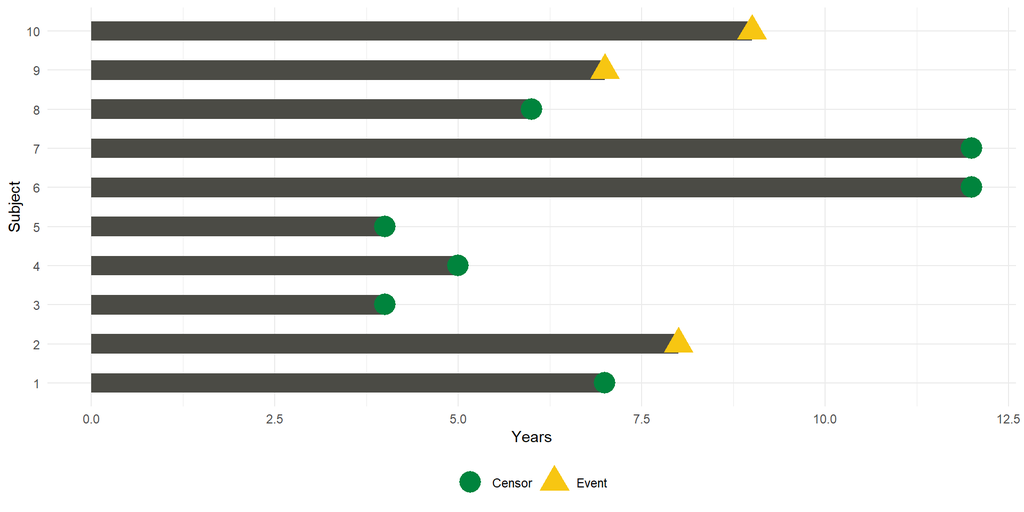

## The {survival} package is the basis of the survival ecosystem in R

[figure not shown]

- Began development in 1985
- Total of 11.9M downloads
- Active development ongoing
- Many detailed vignettes covering both the basics and advanced topics
- Includes the essential methods

```r
install.packages("survival")
library(survival)
```

## Example dataset

The `colon` data come from a clinical trial of adjuvant therapy for colon cancer, and are included in the {survival} package.

Variables of interest:

| Variable | Variable description | Levels |
| --- | --- | --- |
| rx | Treatment assignment | Obs(ervation), Lev(amisole), Lev(amisole)+5-FU |
| sex | Sex | 1=male, 0=female |
| years | Years to status | Continuous years |
| status | Censoring status | 0=censored, 1=recurrence |

See appendix slide for code to generate altered example data `colonr`.

## Estimate median event-free time

Use `survfit()` to create the survival curves from which the median recurrence-free years and 95% confidence interval are obtained:

```r
survfit(Surv(years, status) ~ 1, data = colonr)
```

```
Call: survfit(formula = Surv(years, status) ~ 1, data = colonr)

       n events median 0.95LCL 0.95UCL
[1,] 929    468   5.52    4.01      NA
```

## Estimate x-year event-free probability

Run `summary()` on the `survfit()` object to estimate the 5-year recurrence-free probability and 95% confidence interval:

```r
summary(survfit(Surv(years, status) ~ 1, data = colonr), times = 5)
```

```
Call: survfit(formula = Surv(years, status) ~ 1, data = colonr)

 time n.risk n.event survival std.err lower 95% CI upper 95% CI
    5    437     451    0.508  0.0166        0.476        0.541
```

## Fit Cox regression models

Use `coxph()` to fit univariate and multivariable Cox regression models:

```r
coxph(Surv(years, status) ~ rx, data = colonr)
```

```
Call:
coxph(formula = Surv(years, status) ~ rx, data = colonr)

              coef exp(coef) se(coef)      z        p
rxLev     -0.01512   0.98499  0.10708 -0.141    0.888
rxLev+5FU -0.51209   0.59924  0.11863 -4.317 1.58e-05

Likelihood ratio test=24.34  on 2 df, p=5.175e-06
n= 929, number of events= 468
```

## Plot Kaplan-Meier curves

Run `plot()` on the `survfit()` object to generate the Kaplan-Meier plot:

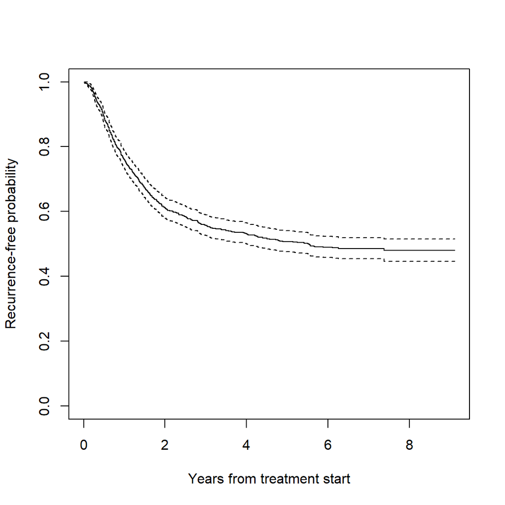

```r
plot(survfit(Surv(years, status) ~ 1, data = colonr),
  xlab = "Years from treatment start",
  ylab = "Recurrence-free probability")
```

## Done! That’s everything we need!

But what if we need to put our results in a reproducible and publication-ready report?

[figure not shown]

```r
install.packages(c("gtsummary", "ggsurvfit"))
library(gtsummary)
library(ggsurvfit)
```

## Survival tables with {gtsummary}

Use `tbl_survfit()` to create:

- Tables of median event-free time
- Tables of x-time event-free probability

Use `tbl_uvregression()` to create:

- Tables of univariate Cox regression results

Use `tbl_regression()` to create:

- Tables of multivariable Cox regression results

Tables are highly customizable, see https://www.danieldsjoberg.com/gtsummary/ for details and vignettes to get started

## Table of median event-free time

Use `tbl_survfit()` with the `probs = 0.5` argument:

```r
list(
  survfit(
    Surv(years, status) ~ 1,
    data = colonr),
  survfit(
    Surv(years, status) ~ rx,
    data = colonr)
  ) |>
  tbl_survfit(
    probs = 0.5,
    label_header =
      "Median (95% CI)"
    )
```

| **Characteristic** | Median (95% CI) |
| --- | --- |
| Overall | 5.5 (4.0, —) |
| Treatment |  |
| Obs | 3.4 (2.2, 5.6) |
| Lev | 3.2 (2.2, 5.7) |
| Lev+5FU | — (—, —) |

- Highly customizable
- Can set labels, titles, subtitles, footnotes, and more

## Table of x-year event-free probability

Use `tbl_survfit()` with the `times = 5` argument:

```r
list(
  survfit(
    Surv(years, status) ~ 1,
    data = colonr),
  survfit(
    Surv(years, status) ~ rx,
    data = colonr)
  ) |>
  tbl_survfit(
    times = 5,
    label_header =
      "{time}-year RFS (95% CI)"
    )
```

| **Characteristic** | 5-year RFS (95% CI) |
| --- | --- |
| Overall | 51% (48%, 54%) |
| Treatment |  |
| Obs | 45% (40%, 51%) |
| Lev | 46% (41%, 52%) |
| Lev+5FU | 62% (56%, 67%) |

- Note the use of {glue} syntax in the label header to dynamically code the column header

## Inline results reporting

Save the `tbl_survfit()` result to an object (here, `tab1`) so that table statistics can be extracted for use inline with the `inline_text()` function.

The inline code:

> The median (95% CI) recurrence-free time for the Levamisole treatment group is `` `r inline_text(tab1, variable = rx, level = 'Lev', prob = 0.5)` ``.

Will show as:

> The median (95% CI) recurrence-free time for the Levamisole treatment group is 3.2 (2.2, 5.7).

## Univariate Cox regression table

Use `tbl_uvregression()`:

```r
colonr |>
  tbl_uvregression(
    method = coxph,
    y = Surv(years, status),
    include = c(rx, sex),
    exponentiate = T
    ) |>
  add_global_p()
```

| **Characteristic** | **N** | **HR** | **95% CI** | **p-value** |
| --- | --- | --- | --- | --- |
| Treatment | 929 |  |  | <0.001 |
| Obs |  | — | — |  |
| Lev |  | 0.98 | 0.80, 1.21 |  |
| Lev+5FU |  | 0.60 | 0.47, 0.76 |  |
| Sex | 929 |  |  | 0.4 |
| Female |  | — | — |  |
| Male |  | 0.92 | 0.77, 1.10 |  |

Abbreviations: CI = Confidence Interval, HR = Hazard Ratio

- Fits models for all variables listed in `include =`
- `exponentiate = T` to obtain hazard ratios
- Add global p-values

## Multivariable Cox regression table

Pass fitted model results directly to `tbl_regression()`:

```r
coxph(
  Surv(years, status) ~
    rx + sex,
  data = colonr
  ) |>
  tbl_regression(
    exponentiate = T
  ) |>
  add_global_p()
```

| **Characteristic** | **HR** | **95% CI** | **p-value** |
| --- | --- | --- | --- |
| Treatment |  |  | <0.001 |
| Obs | — | — |  |
| Lev | 0.99 | 0.80, 1.22 |  |
| Lev+5FU | 0.60 | 0.47, 0.75 |  |
| Sex |  |  | 0.3 |
| Female | — | — |  |
| Male | 0.90 | 0.75, 1.08 |  |

Abbreviations: CI = Confidence Interval, HR = Hazard Ratio

## Time-to-event plots with {ggsurvfit}

Uses {ggplot2} as the basis so known customizations are available with the `+` operator.

- Plot Kaplan-Meier curves using `ggsurvfit`
- Plot cumulative incidence curves for competing risks using `ggcuminc`
- Plot multi-state models using `ggsurvfit`

Options to:

- Add confidence intervals
- Add risk tables
- Add quantiles
- And more

See https://www.danieldsjoberg.com/ggsurvfit/ for details and vignettes to get started

## Kaplan-Meier curves with ggsurvfit()

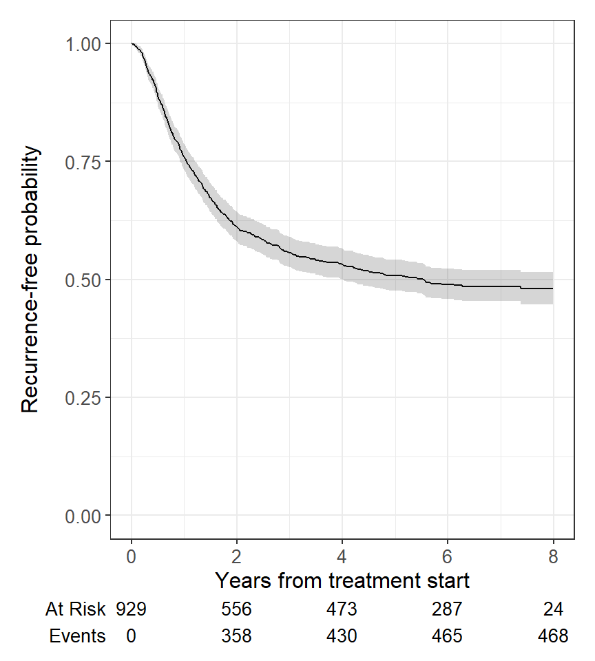

```r
survfit2(
  Surv(years, status) ~ 1,
  data = colonr
  ) |>
  ggsurvfit() +
  add_confidence_interval() +
  add_risktable() +
  scale_y_continuous(
    limits = c(0, 1)
    ) +
  scale_x_continuous(
    limits = c(0, 8),
    breaks = seq(0, 8, 2)
  ) +
  labs(
    x = "Years from treatment start",
    y = "Recurrence-free probability"
  )
```

## Put it all together

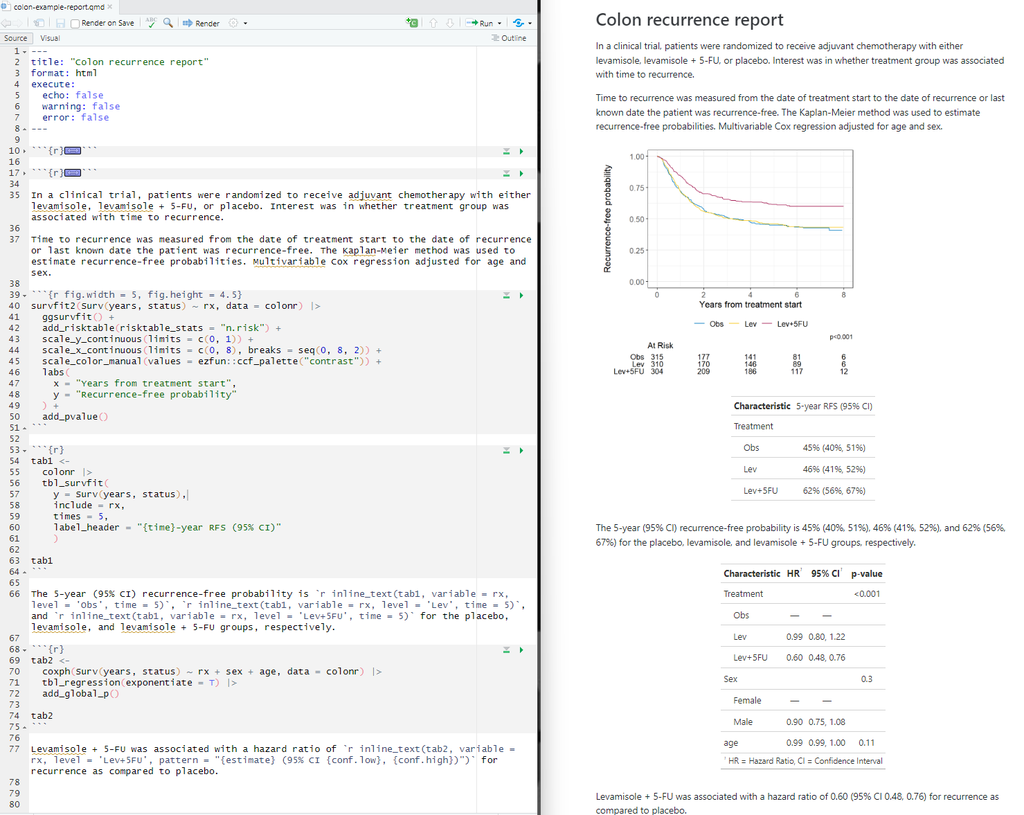

## Thank you, and please get in touch

zabore2@ccf.org

https://www.emilyzabor.com/

https://github.com/zabore

https://www.linkedin.com/in/emily-zabor-59b902b7/

Link to slides: https://github.com/zabore/slidedecks/blob/master/2024-NYR-Zabor.html

[figure not shown]

https://rconsortium.github.io/RMedicine_website/

## Appendix: Create example dataset

- `colon` dataset from {survival} altered to:
  - Limit to one row per patient with interest in recurrence rather than death
  - Scale time from days to years
  - Recode sex levels to informative values
  - Label variables of interest

```r
colonr <-
  colon |>
  filter(etype == 1) |>
  mutate(
    years = time / 365.25,
    sex = case_match(
      sex,
      0 ~ "Female",
      1 ~ "Male"
    )
  ) |>
  labelled::set_variable_labels(
    rx = "Treatment",
    sex = "Sex"
  )
```